# R Notebook

```r
library(car)
library(MASS)
library(plotrix)
```

# Exercise 2

## a)

```r
ker <- read.table("http://www-eio.upc.es/~jan/Data/MVA/kernels.dat", header=T)
head(ker)
```

|  | area | perimeter | compactness | length | width | asymmetry | groove |
| --- | --- | --- | --- | --- | --- | --- | --- |
| 1 | 15.26 | 14.84 | 0.8710 | 5.763 | 3.312 | 2.221 | 5.220 |
| 2 | 14.88 | 14.57 | 0.8811 | 5.554 | 3.333 | 1.018 | 4.956 |
| 3 | 14.29 | 14.09 | 0.9050 | 5.291 | 3.337 | 2.699 | 4.825 |
| 4 | 13.84 | 13.94 | 0.8955 | 5.324 | 3.379 | 2.259 | 4.805 |
| 5 | 16.14 | 14.99 | 0.9034 | 5.658 | 3.562 | 1.355 | 5.175 |
| 6 | 14.38 | 14.21 | 0.8951 | 5.386 | 3.312 | 2.462 | 4.956 |

## b) Perimeter and area are the most correlated.

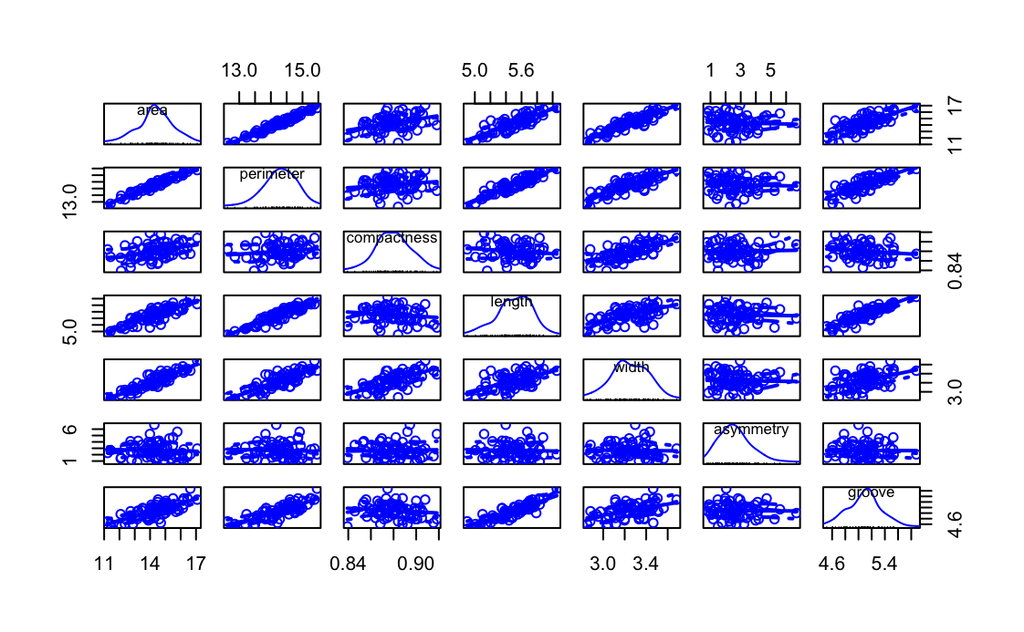

```r
scatterplotMatrix(ker)
```

```r
cor(ker)
```

```
                   area   perimeter compactness      length       width
area         1.00000000  0.97643665  0.37103733  0.83477809  0.90006617
perimeter    0.97643665  1.00000000  0.16492283  0.92120227  0.80235953
compactness  0.37103733  0.16492283  1.00000000 -0.14630391  0.66657308
length       0.83477809  0.92120227 -0.14630391  1.00000000  0.55056053
width        0.90006617  0.80235953  0.66657308  0.55056053  1.00000000
asymmetry   -0.05048194 -0.05394128  0.03695775 -0.03668859 -0.02667164
groove       0.72095279  0.79367796 -0.13107635  0.86615879  0.44711056
              asymmetry      groove
area        -0.05048194  0.72095279
perimeter   -0.05394128  0.79367796
compactness  0.03695775 -0.13107635
length      -0.03668859  0.86615879
width       -0.02667164  0.44711056
asymmetry    1.00000000 -0.01101627
groove      -0.01101627  1.00000000
```

## c) Seems that 2 components are enough.

```r
ker2 <- scale(ker)
acp <- princomp(ker2)
summary(acp)
```

```
Importance of components:
                          Comp.1    Comp.2    Comp.3     Comp.4
Standard deviation     2.0359084 1.2225556 0.9922068 0.45322847
Proportion of Variance 0.6007135 0.2166148 0.1426774 0.02977044
Cumulative Proportion  0.6007135 0.8173283 0.9600057 0.98977618
                            Comp.5      Comp.6       Comp.7
Standard deviation     0.223638552 0.141269676 2.393861e-02
Proportion of Variance 0.007248435 0.002892336 8.305173e-05
Cumulative Proportion  0.997024612 0.999916948 1.000000e+00
```

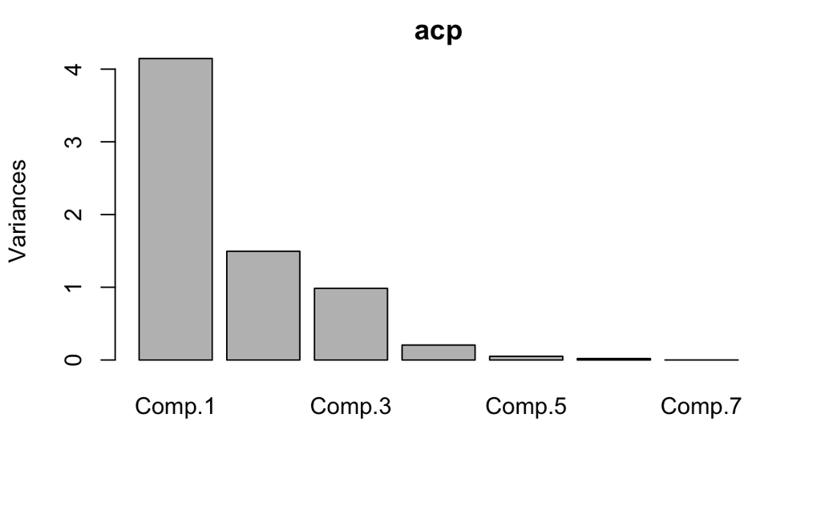

```r
screeplot(acp)
```

## d) The second component is principally afected by the compactness. While the first one is almost a mean, except for compactness. It can be seen as the second component almost being compactness and the first the rest.

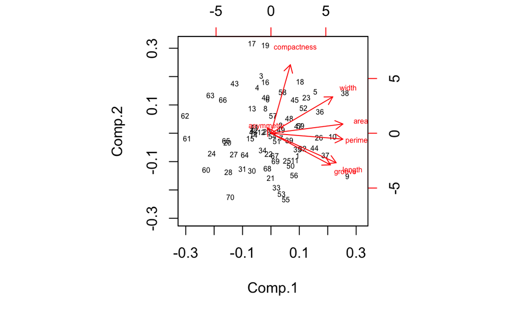

```r
biplot(acp, cex=0.5)
```

## e) Length and groove, it isn’t the same as the one given by the correlation matrix

## f) It is greater in all components

```r
apply(acp$scores, 2, sd)
```

```
    Comp.1     Comp.2     Comp.3     Comp.4     Comp.5     Comp.6
2.05060830 1.23138284 0.99937082 0.45650092 0.22525329 0.14228969
    Comp.7
0.02411145
```

```r
acp$sdev
```

```
    Comp.1     Comp.2     Comp.3     Comp.4     Comp.5     Comp.6
2.03590841 1.22255561 0.99220678 0.45322847 0.22363855 0.14126968
    Comp.7
0.02393861
```

## g) It gives the projection matrix.

```r
acp$loadings
```

```
Loadings:
            Comp.1 Comp.2 Comp.3 Comp.4 Comp.5 Comp.6 Comp.7
area         0.481  0.103         0.160         0.456  0.722
perimeter    0.481                0.270         0.485 -0.675
compactness  0.130  0.764        -0.389  0.475        -0.149
length       0.436 -0.329         0.211  0.597 -0.546
width        0.413  0.406         0.189 -0.608 -0.508
asymmetry                 -0.996
groove       0.398 -0.352        -0.817 -0.211

               Comp.1 Comp.2 Comp.3 Comp.4 Comp.5 Comp.6 Comp.7
SS loadings     1.000  1.000  1.000  1.000  1.000  1.000  1.000
Proportion Var  0.143  0.143  0.143  0.143  0.143  0.143  0.143
Cumulative Var  0.143  0.286  0.429  0.571  0.714  0.857  1.000
```

## h) It gives more or less the same result, except for the arrows which aren’t plotted.

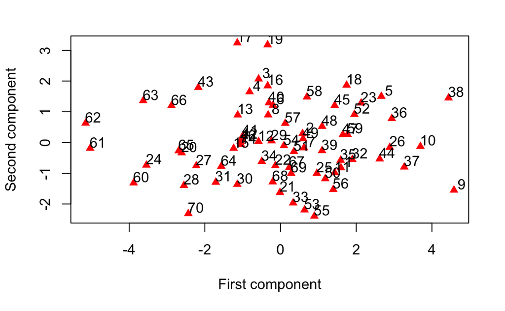

```r
plot(acp$scores[,1], acp$scores[,2], xlab="First component", ylab="Second component", pch=17, col="red")
text(acp$scores[,1]+0.2, acp$scores[,2]+0.2, labels=rownames(ker))
```

## i) The correlation between different principal components is almost 0, as expected, i.e. the variables are independent.

```r
cor(as.matrix(acp$scores))
```

```
              Comp.1        Comp.2        Comp.3        Comp.4
Comp.1  1.000000e+00  1.114776e-16 -2.863031e-18 -6.159107e-16
Comp.2  1.114776e-16  1.000000e+00  2.092075e-16  1.212260e-15
Comp.3 -2.863031e-18  2.092075e-16  1.000000e+00 -8.553762e-16
Comp.4 -6.159107e-16  1.212260e-15 -8.553762e-16  1.000000e+00
Comp.5 -3.769384e-16  1.906339e-15  1.130203e-15 -2.466619e-15
Comp.6 -3.362674e-15  5.368211e-16  4.469410e-15  1.947465e-15
Comp.7 -1.134441e-14 -9.451872e-15 -2.075367e-14  1.411479e-14
              Comp.5        Comp.6        Comp.7
Comp.1 -3.769384e-16 -3.362674e-15 -1.134441e-14
Comp.2  1.906339e-15  5.368211e-16 -9.451872e-15
Comp.3  1.130203e-15  4.469410e-15 -2.075367e-14
Comp.4 -2.466619e-15  1.947465e-15  1.411479e-14
Comp.5  1.000000e+00  8.593496e-16 -4.955240e-14
Comp.6  8.593496e-16  1.000000e+00  3.260248e-14
Comp.7 -4.955240e-14  3.260248e-14  1.000000e+00
```

## j)

```r
X <- scale(ker)
Y = svd(X)
print(Y$d)
```

```
[1] 17.0336319 10.2286341  8.3013975  3.7919814  1.8710944  1.1819469
[7]  0.2002848
```

## k)

```r
pc <- Y$u%*%diag(Y$d)
head(pc)
```

```
           [,1]       [,2]       [,3]        [,4]         [,5]
[1,] -1.5957328  0.8206821 -0.3157637  0.46767917 -0.075191143
[2,] -0.5822900 -0.2893664 -1.4486292  0.64601861  0.018724188
[3,]  0.5784016 -2.0678495 -0.1152505  0.01427686 -0.071327688
[4,]  0.8191770 -1.6509794 -0.4794181  0.23054341  0.257216804
[5,] -2.6628361 -1.5017946 -1.1585181  0.14703854  0.024864032
[6,]  0.1987344 -1.2149506 -0.2539833 -0.03637763 -0.008173573
             [,6]        [,7]
[1,] -0.004573267 -0.00363088
[2,]  0.060115607 -0.01428786
[3,]  0.083835223 -0.02380646
[4,] -0.418473956 -0.03059510
[5,] -0.009951482  0.02170931
[6,]  0.051965662 -0.01922961
```

## l)

```r
plot(pc[,1:2], xlab="", ylab="")
arrows(x0=rep(0,7),y0=rep(0,7),x1=t(Y$v[1,1:7]),y1=t(Y$v[2,1:7]), length = 0.1, col="red")
```

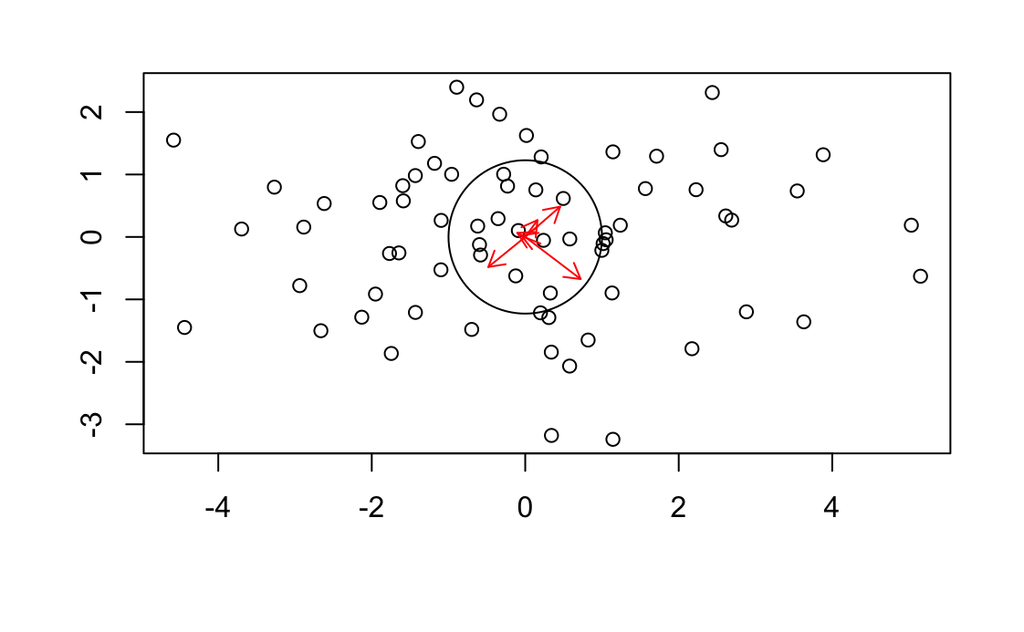

```r
draw.circle(0,0,radius=1)
```

## m) The variable number 6 which corresponds with asymmetry. The reason is that this variable is represented almost totally by the third component.

```r
which.min((abs(Y$v[,1])+abs(Y$v[,2]))/sum(abs(Y$v[,1:7])))
```

```
[1] 6
```